# NHL Contract Year Effects: Player Performance and Expectations (2014/2015-2024/2025)

### 3.5 Games Played Distribution

We want to find a reasonable minimum Games Played threshold so that per-season performance stats represent meaningful playing time without eliminating too much of our data.  
First, let's inspect the overall Games Played distribution:

```python
df['gamesPlayed'].describe()
```

```
count      11784.0
mean     46.976239
std       28.16857
min            1.0
25%           19.0
50%           52.0
75%           73.0
max           85.0
Name: gamesPlayed, dtype: Float64
```

Now let's test several possible cutoffs in increments of ten to see how many rows each would retain from our dataset:

```python
thresholds = [10, 20, 30, 40, 50]

for t in thresholds:
    count = (df['gamesPlayed'] >= t).sum()
    print(f"Games Played >= {t}: {count} rows ({count/len(df):.2%} of dataset)")
```

```
Games Played >= 10: 9748 rows (82.72% of dataset)
Games Played >= 20: 8822 rows (74.86% of dataset)
Games Played >= 30: 8100 rows (68.74% of dataset)
Games Played >= 40: 7311 rows (62.04% of dataset)
Games Played >= 50: 6175 rows (52.40% of dataset)
```

To keep an appropriate balance, we'll use **≥ 25** as a Games Played cutoff going forward. This retains around **70% of our dataset** and since the NHL season consists of 82 games, that gives us about **30% of the season** as a minimum to consider the stats relevant.

### 3.6 Summary

After inspecting the dataset, we removed exact duplicate rows and resolved duplicate player-season entries where the *free_agent_type* different.  
The dataset contains **2,419 unique players**, with a **mean of ~5 seasons per player**. Across all player-seasons, **contract years represent ~45%** of seasons per player. About **65% of player-seasons are forwards**, with the remainder representing defensemen. Finally, we decided on use a **minimum of 25 games played per season** as an appropriate cutoff to ensure meaningful player statistics while retaining the majority (**~70%**) of the dataset.

## 4. Filtering and Preparing Data for Analysis

To ensure robust within-player comparisons, this section applies two key filters:

- a minimum playing-time requirement and
- a requirement that players must have both contract-year and non-contract-year seasons

In this section, we will create the final analytic dataset for all performance comparisons. The goal of this filtering is to ensure that every player has enough meaningful playing time and at least one contract-year season and one non-contract-year season, allowing us to make valid comparisons within each player's stats.

### 4.1 Minimum Games Played Filter

To remove player-seasons with extremely limited playing time, we'll apply a minimum threshold of **25 games played**. This cutoff balances sample size with reliability. 25 games represents approximately **30%** of the season, so the cutoff helps to eliminate partial and injury-shortened seasons that could otherwise distort the player performance metrics, while still including seasons with meaningful statistics.

```python
df_filtered = df[df["gamesPlayed"] >= 25].copy()
print("Remaining rows:", len(df_filtered))
print("Remaining players:", df_filtered['playerId'].nunique())
```

```
Remaining rows: 8463
Remaining players: 1712
```

### 4.2 Contract Year and Non-Contract Year Filter

Because our analysis relies on *within-player* comparisons of contract-year vs non-contract-year performance, we must exclude any player who does not have at least one season of each type.

```python
# Count contract vs non-contract seasons per player
year_counts = df_filtered.groupby("playerId")["contract_year"].agg(
    contract_season="sum",
    total_seasons="count"
)

# Calculate the non-contract seasons
year_counts["non-contract_season"] = year_counts["total_seasons"] - year_counts["contract_season"]

# Reorder columns
year_counts = year_counts[["contract_season", "non-contract_season", "total_seasons"]]

year_counts.head()
```

| playerId | contract_season | non-contract_season | total_seasons |
| --- | --- | --- | --- |
| 8448208 | 5 | 0 | 5 |
| 8457981 | 1 | 1 | 2 |
| 8458537 | 1 | 1 | 2 |
| 8458590 | 1 | 0 | 1 |
| 8458951 | 1 | 2 | 3 |

```python
# Players with zero contract seasons
zero_contract = (year_counts["contract_season"] == 0).sum()

# Players with zero non-contract seasons
zero_noncontract = (year_counts["non-contract_season"] == 0).sum()

# Total players that fail the requirement (either condition)
players_to_drop = ((year_counts["contract_season"] == 0) |
                   (year_counts["non-contract_season"] == 0)).sum()

print("Players with no contract seasons:", zero_contract)
print("Players with no non-contract seasons:", zero_noncontract)
print("Total players to drop:", players_to_drop)
```

```
Players with no contract seasons: 255
Players with no non-contract seasons: 261
Total players to drop: 516
```

Now that we have the *year_counts* dataframe, we'll use it to create a new *df_final* dataset with these 516 players removed.

```python
# Identify valid players
valid_players = year_counts[
    (year_counts["contract_season"] > 0) &
    (year_counts["non-contract_season"] > 0)
].index

# Apply to df_filtered and store in a new dataframe
df_final = df_filtered[df_filtered["playerId"].isin(valid_players)]

print("Original players:", df_filtered["playerId"].nunique())
print("Original rows:", len(df_filtered))
print("Remaining players:", df_final["playerId"].nunique())
print("Remaining rows:", len(df_final))
```

```
Original players: 1712
Original rows: 8463
Remaining players: 1196
Remaining rows: 7537
```

After applying both filters, our new dataset now retains **1,196 players** and **7,537** player-seasons, which provides a sufficiently large sample size while ensuring reliable performance comparisons between contract and non-contract seasons.

## 5. Arranging Player-Level Data for Analysis

Before we can compare contract-year vs non-contract-year performance, we need to restructure the season-level dataset into a player-level format. Each player will have a single row containing their average stats in contract-year seasons and non-contract-year seasons.  
This section will:

- Create a pivot table separating contract and non-contract averages
- Add a *performance_tier* column (low, mid, high) based on each player's average points per 60 minutes across all seasons
- Allow us to quickly filter, group, and reference player statistics in later analyses

### 5.1 Creating a Player-Level Pivot Table for Contract vs Non-Contract Seasons

To simplify our data analysis in later sections, we will convert the filtered season-level dataset into a player-level dataset. Instead of storing one row per season, we'll create a pivot table that summarizes each player's **average performance in contract-year seasons and non-contract-year seasons**.

This transformation lets us easily compute within-player comparisons, because each statistic will now have two separate columns, one for *contract year* and one for *non-contract year*, ending in "_con" and "non" respectively. Only usable performance metrics are included in the pivot.

```python
metrics = [
    "goals", "assists", "points", "points_per_60",
    "plusMinus", "shots", "timeOnIcePerGame_m"
]

pivot = df_final.pivot_table(
    index="playerId",
    columns="contract_year",
    values=metrics,
    aggfunc="mean"
)

# Rename contract_year 1 to “_con” and 0 to “_non”
rename_map = {0: "non", 1: "con"}

pivot.columns = [f"{metric}_{rename_map[season]}" for metric, season in pivot.columns]
pivot.reset_index(inplace=True)

pivot.head()
```

|  | playerId | assists_non | assists_con | goals_non | goals_con | plusMinus_non | plusMinus_con | points_non | points_con | points_per_60_non | points_per_60_con | shots_non | shots_con | timeOnIcePerGame_m_non | timeOnIcePerGame_m_con |
| --- | --- | --- | --- | --- | --- | --- | --- | --- | --- | --- | --- | --- | --- | --- | --- |
| 0 | 8457981 | 18.0 | 12.0 | 9.0 | 12.0 | 8.0 | -10.0 | 27.0 | 24.0 | 1.791870 | 1.994874 | 111.0 | 96.0 | 14.126302 | 15.692390 |
| 1 | 8458537 | 18.0 | 23.0 | 11.0 | 9.0 | 1.0 | -6.0 | 29.0 | 32.0 | 2.803437 | 1.992804 | 62.0 | 124.0 | 19.395833 | 13.963285 |
| 2 | 8458951 | 16.5 | 24.0 | 1.5 | 3.0 | -3.0 | 4.0 | 18.0 | 27.0 | 0.987819 | 1.500440 | 67.5 | 85.0 | 17.649140 | 23.992962 |
| 3 | 8460496 | 11.0 | 13.0 | 2.0 | 10.0 | -5.0 | -18.0 | 13.0 | 23.0 | 1.079709 | 1.242646 | 69.0 | 129.0 | 15.370567 | 15.424073 |
| 4 | 8460542 | 28.0 | 22.0 | 15.5 | 14.0 | -12.0 | 5.0 | 43.5 | 36.0 | 2.206054 | 2.403918 | 115.0 | 118.0 | 17.760757 | 18.719443 |

### 5.2 Categorizing Players by Performance Level

Next, we'll categorize players by their overall skill level. While we could use different stats for forwards and defensemen, we decided to use **points_per_60** as a single metric for all players. This keeps the analysis simple, consistent, and avoids the noise inherent in *plusMinus*.

Players will be grouped into three categories based on performance: **Stars** (top 25%), **Mid-Level** (middle 50%), and **Lower-Tier** (bottom 25%). This will allow us to clearly distinguish elite players from the middle and lower tiers.

Rather than ranking players season by season, we'll calculate each player's **average points_per_60** across all seasons. This average will determine their tier, and the result will be stored in a new column, **performance_tier** in the *df_final* dataframe for analysis.

```python
# Create a dataframe that calculates each player's average points_per_60 across all their seasons
player_avgs = df_final.groupby("playerId")["points_per_60"].mean().reset_index()
player_avgs.rename(columns={"points_per_60": "avg_points_per_60"}, inplace=True)

# Compute the quartile thresholds using player averages
q25 = player_avgs["avg_points_per_60"].quantile(0.25)
q75 = player_avgs["avg_points_per_60"].quantile(0.75)

# Assignment function
def assign_tier(x):
    if x <= q25:
        return "low"
    elif x <= q75:
        return "mid"
    else:
        return "high"

# Add new column based on tier assignment function
player_avgs["performance_tier"] = player_avgs["avg_points_per_60"].apply(assign_tier)

# Merge the new performance_tier column back into the df_final dataframe
df_final = df_final.merge(player_avgs[["playerId", "performance_tier"]], on="playerId", how="left")

# Convert the performance_tier column to an ordered categorical datatype (Keeps tiers in order for later analysis and data viz)
df_final["performance_tier"] = pd.Categorical(
    df_final["performance_tier"],
    categories=["low", "mid", "high"],
    ordered=True
)

# Show results (how many player-seasons in each category)
print ("Player-Seasons")
print (df_final["performance_tier"].value_counts().sort_index())
print ()
print ("Unique Players")
print (df_final.groupby("performance_tier", observed=True)["playerId"].nunique().sort_index())
```

```
Player-Seasons
performance_tier
low     1639
mid     3534
high    2364
Name: count, dtype: int64

Unique Players
performance_tier
low     299
mid     598
high    299
Name: playerId, dtype: int64
```

## 6. Analyzing Performance Differences Between Contract and Non-Contract Seasons

In this section, we compare each player's performance in *contract-year* seasons to their performance in *non-contract-year* seasons. All analyses will be based on within-player differences rather than comparisons across players.  
We will:

- Calculate the average difference (*delta*) between contract-year and non-contract-year statistics for each player
- Compute standard deviations to assess whether observed differences exceed expected variability
- Visualize the distributions of differences to see patterns, or lack thereof
- Perform subgroup analyses by player position, performance tier, etc
- Analyze time on ice per game to determine whether coaches are influenced by players' contract year

### 6.1 Comparing Contract vs Non-Contract Performance

Now that we've built our pivot table containing each player's average performance during contract and non-contract seasons, we can begin comparing how players perform in their contract years.

To quantify this, we'll calculate a **delta** for each performance statistic.  
`delta = (contract-year average) − (non-contract-year average)`

We'll take the average delta value per stat for each player, reflecting how their output changes when they are in a contract season.  
We then compute the **overall mean delta** (are players better or worse in their contract years on average?) and the **standard deviation** (how much natural variation exists across all players?).

```python
# Calculate the deltas
pivot["points_per_60_delta"] = pivot["points_per_60_con"] - pivot["points_per_60_non"]
pivot["plusMinus_delta"] = pivot["plusMinus_con"] - pivot["plusMinus_non"]
pivot["timeOnIcePerGame_m_delta"] = pivot["timeOnIcePerGame_m_con"] - pivot["timeOnIcePerGame_m_non"]

print ("Mean")
print (pivot[["points_per_60_delta", "plusMinus_delta", "timeOnIcePerGame_m_delta"]].mean())
print ()
print ("Standard Deviation")
print (pivot[["points_per_60_delta", "plusMinus_delta", "timeOnIcePerGame_m_delta"]].std())
```

```
Mean
points_per_60_delta        -0.034499
plusMinus_delta             0.171636
timeOnIcePerGame_m_delta   -0.391345
dtype: Float64

Standard Deviation
points_per_60_delta         0.384314
plusMinus_delta             9.986646
timeOnIcePerGame_m_delta    1.727993
dtype: Float64
```

#### 6.1.1 Average Contract vs Non-Contract Differences (Mean ± Standard Deviation)

We compared each player's average performance in contract-year seasons to their average performance in non-contract-year seasons.  
For each metric, we show the mean difference (contract - non-contract) as a bar, with error bars representing ±1 standard deviation.

Because the magnitude of *plusMinus* is much larger than *points_per_60* or *timeOnIcePerGame_m*, we separate the metrics into side-by-side subplots with independent Y axes. This makes it easier to see both the tiny average differences and the large variability.

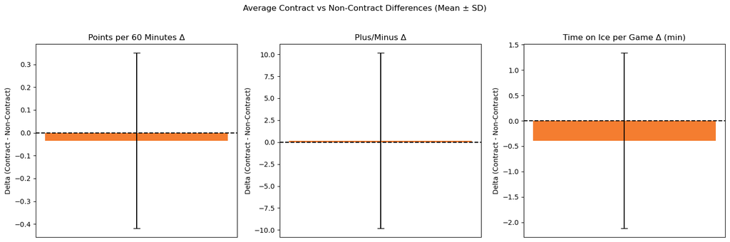

```python
import matplotlib.pyplot as plt

metrics = ["points_per_60_delta", "plusMinus_delta", "timeOnIcePerGame_m_delta"]
new_titles = {
    "points_per_60_delta": "Points per 60 Minutes Δ",
    "plusMinus_delta": "Plus/Minus Δ",
    "timeOnIcePerGame_m_delta": "Time on Ice per Game Δ (min)"
}
means = pivot[metrics].mean()
stds = pivot[metrics].std()

fig, axes = plt.subplots(1, 3, figsize=(15,5))

for ax, metric in zip(axes, metrics):
    ax.bar(0, means[metric], yerr=stds[metric], capsize=5, color="#f47d30")
    ax.axhline(0, color='black', linestyle="--")
    ax.set_title(metric)
    ax.set_xticks([])
    ax.set_title(new_titles[metric])
    ax.set_ylabel("Delta (Contract - Non-Contract)")


plt.suptitle("Average Contract vs Non-Contract Differences (Mean ± SD)")
plt.tight_layout(rect=[0, 0, 1, 0.95])
plt.show()
```

The bars representing each mean difference are very small. That, combined with such large error bars, suggests that the differences (deltas) are **largely within expected variability (noise)** rather than reflecting any consistent contract-year effect.

#### 6.1.2 Contract vs Non-Contract Performance: Points per 60 Minutes

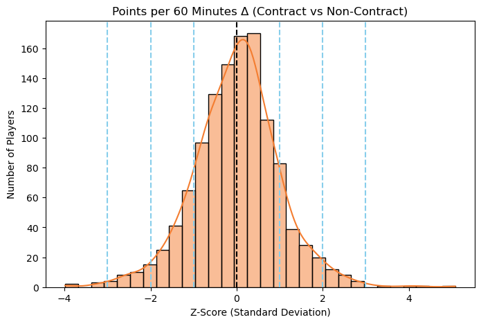

```python
import seaborn as sns

# Metric to use
metric = "points_per_60_delta"

# Calculate Z-score
z_scores = (pivot[metric] - pivot[metric].mean()) / pivot[metric].std()

plt.figure(figsize=(8,5))
sns.histplot(z_scores, bins=30, kde=True, color="#f47d30")
plt.axvline(0, color='black', linestyle="--")
for sd in [1, 2, 3]:
    plt.axvline(sd, color="skyblue", linestyle="--")
    plt.axvline(-sd, color="skyblue", linestyle="--")
plt.title("Points per 60 Minutes Δ (Contract vs Non-Contract)")
plt.xlabel("Z-Score (Standard Deviation)")
plt.ylabel("Number of Players")
plt.show()
```

The histogram shows that the vast majority of players have differences close to zero, with most falling within ± 1 standard deviation. This indicates that for most players, **contract-year performance does not deviate substantially from non-contract year performance**. Any changes are **largely within expected variation** and suggest **no consistent *contract year effect* on points per 60 minutes**.

### 6.2 Performance Differences by Player Tier

Although our overall results show that most contract-year differences fall within one standard deviation, it's possible that player performance varies more across skill levels. Here, we will use our grouped player performance tiers of **Low**, **Mid**, and **High** based on their average points per 60 minutes. We then compare the contract vs non-contract deltas for each tier separately to see if any subgroup shows a larger or more consistent effect.

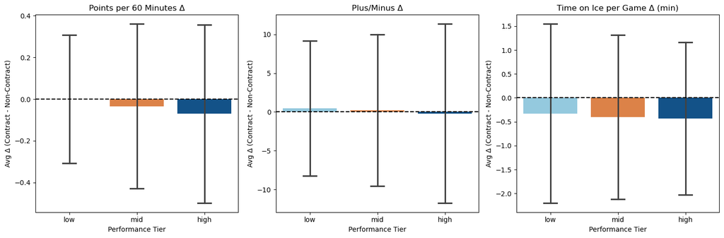

```python
metrics = ["points_per_60_delta", "plusMinus_delta", "timeOnIcePerGame_m_delta"]
metric_labels = {
    "points_per_60_delta": "Points per 60 Minutes Δ",
    "plusMinus_delta": "Plus/Minus Δ",
    "timeOnIcePerGame_m_delta": "Time on Ice per Game Δ (min)"
}

tier_mapping = df_final.groupby("playerId")["performance_tier"].first()
pivot["performance_tier"] = pivot["playerId"].map(tier_mapping)

colors = {"low": "skyblue", "mid": "#f47d30", "high": "#00539b"}

fig, axes = plt.subplots(1, 3, figsize=(15,5), sharey=False)

for ax, metric in zip(axes, metrics):
    sns.barplot(
        x="performance_tier",
        y=metric,
        data=pivot,
        hue="performance_tier",
        palette=colors,
        errorbar="sd",
        capsize = 0.2,
        ax=ax
    )
    ax.set_title(metric_labels[metric])
    ax.set_xlabel("Performance Tier")
    ax.set_ylabel("Avg Δ (Contract - Non-Contract)")
    ax.axhline(0, color="black", linestyle="--")

plt.tight_layout()
plt.show()
```

While there are slight differences in contract vs non-contract deltas between the performance tiers, all values remain well within the overall standard deviations. This indicates that there is **no statistically meaningful differences in seasonal performance across tiers**.

### 6.3 Performance Differences by Position (Forwards vs Defensemen)

At this point, the overall analysis, as well as our performance-tier subgrouping, has shown no statistically significant difference between contract-year and non-contract year performance or time on ice. All observed deltas fall well within normal season-to-season variability.

To complete our subgroup comparison, we'll now examine whether this pattern holds when players are separated by position. Since forwards and defensemen have fundamentally different roles, scoring rates, and usage patterns, it is still possible that contract-year effects might manifest differently between the two groups.

We will divide the dataset into **forwards (C, LW, RW)** and **defensemen (D)** and compute contract vs non-contract deltas for each group in the same manner as previous sections. We will consider defensemen to be any player that includes "D" in their *positionCode* column for 50% or more of their seasons.

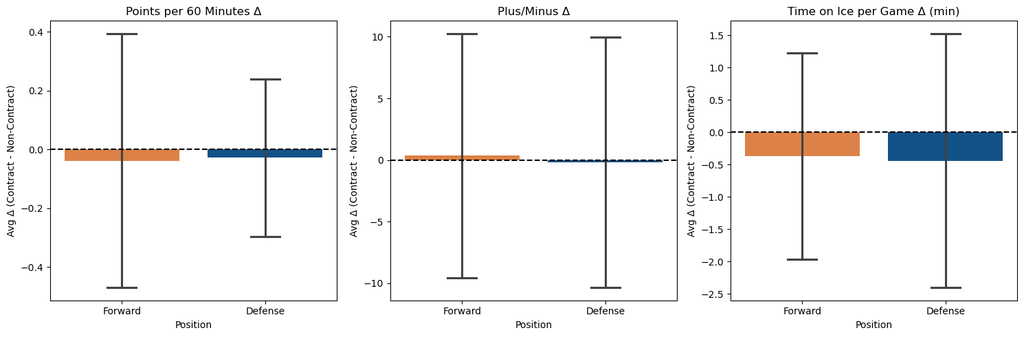

```python
metrics = ["points_per_60_delta", "plusMinus_delta", "timeOnIcePerGame_m_delta"]
metric_labels = {
    "points_per_60_delta": "Points per 60 Minutes Δ",
    "plusMinus_delta": "Plus/Minus Δ",
    "timeOnIcePerGame_m_delta": "Time on Ice per Game Δ (min)"
}

# Determine whether a player is a defenseman using the 50% rule
player_pos = (
    df_final
    .assign(is_def=lambda df: df["positionCode"].str.contains("D"))
    .groupby("playerId")["is_def"]
    .mean()   # percentage of rows where "D" appears
    .reset_index()
)

# Classify players
player_pos["position_group"] = player_pos["is_def"].apply(
    lambda p: "Defense" if p >= 0.5 else "Forward"
)

# Merge into a copy of the pivot for plotting
pivot_pos = pivot.merge(player_pos[["playerId", "position_group"]], on="playerId", how="left")

colors = {"Forward": "#f47d30", "Defense": "#00539b"}

fig, axes = plt.subplots(1, 3, figsize=(15,5), sharey=False)

for ax, metric in zip(axes, metrics):
    sns.barplot(
        x="position_group",
        y=metric,
        data=pivot_pos,
        hue="position_group",
        palette=colors,
        errorbar="sd",
        capsize = 0.2,
        ax=ax
    )
    ax.set_title(metric_labels[metric])
    ax.set_xlabel("Position")
    ax.set_ylabel("Avg Δ (Contract - Non-Contract)")
    ax.axhline(0, color="black", linestyle="--")

plt.tight_layout()
plt.show()
```

Across all three metrics (**Points per 60 Minutes**, **Plus/Minus**, and **Time on Ice per Game**), forwards and defensement showed **very small average contract-year vs non-contract-year differences**. All of the statistics were **well within one standard deviation**.

There was very little variation between positions and the magnitude remained extremely small relative to normal player-to-player variation. This indicates that neither forwards nor defensemen exhibit statistically meaningful "contract-year effect."

**Taken together, these analyses support the main takeaway that the "contract-year effect" does not appear in our dataset for overall player performance, ice time, or within any of the selected subgroups of NHL skaters.**

## 7. Overall Conclusion

When breaking players into finer subgroups, such as **high**, **mid**, and **low** level performers or **forwards** vs **defensemen**, no category showed a meaningful contract-year performance difference. All observed differences were well within one standard deviation, indicating the fluctuations are indistinguishable from normal player-to-player and season-to-season variability.

Taken as a whole, the results provide strong evidence **against** the common belief that NHL players elevate their performance in contract years, or that coaches, believing this, might put these players out on the ice for more minutes per game. Performance appears relatively stable, and coaching decisions regarding ice time do not seem influenced by contract status.

## 8. Study Limitations and Recommendations for Further Analysis

### 8.1 Study Limitations

While this analysis provides a thorough exploration of contract-year performance effects, several limitations should be kept in mind:

1. Data Scope
   - The dataset examines only a range of 13 seasons from 2012/2013 to 2024/2025
   - Only regular season games were included
   - Some more advanced performance metrics (e.g., expected goals, Corsi/Fenwick, RAPM) were not included
   - Goalies were excluded entirely
   - Performance data was retrieved from the NHL's publicly available statistics interface (unofficial API access)
   - Contract year data was scraped Sportrac, combining information from three separate tables: Signed Free Agents, Available Free Agents, and Contract Extensions
2. Methodological Simplifications
   - Contract-year identification is binary and does not distinguish between Restricted and Unrestricted free agents or contract length
   - Team and line effects (quality of teammates, zone starts, usage context) were not controlled for
   - Simple within-player averages were used rather than any more complex statistical models
   - Contract and non-contract averages were compared across a player's entire set of seasons, rather than only proximal seasons
3. Potential Noise in Seasonal Stats
   - Single-season plus/minus can be influenced heavily by team and line strength
   - Points per 60 minutes can be influenced heavily by injuries, team and line strength, and special team usage

### 8.2 Recommended Next Steps

Further analysis could explore:

- Regression-based models to isolate contract-year effects while controlling for team, age, and usage
- Separate analyses for UFS vs RFA contract years
- Incorporating advanced analytics for more granular performance insight
- Studying goalie performance
- Long-term trends, such as whether contract-year incentives differ across eras
- Comparing proximal seasons directly (comparing a contract year only to the immediately preceding seasons, rather than to all non-contract years combined)

## 9. Data Sources and Citations

- **NHL Statistics API**  
  National Hockey League. *NHL Stats API.* Web. Accessed Jan 2026. https://statsapi.web.nhl.com/api/v1/

  ```
  Publicly accessible NHL stats endpoint used to retrieve player-season performance data. (Unofficial API, accessed via publicly available endpoints)
  ```

- **Spotrac**  
  Sportrac. *NHL Player Contracts and Salary Data.* Web. Accessed Jan 2026.  
  https://www.spotrac.com/nhl/free-agents/signed  
  https://www.spotrac.com/nhl/contracts/extensions

  ```
  Used to identify contract seasons via:
      - Signed Free Agents
      - Available Free Agents
      - Contract Extensions
  ```